# Problem Set 9

Aakash Ahuja

11/7/2019

**Ans 1**

```r
#Scanning the data
Question1Data<-scan("http://mypage.iu.edu/~mtrosset/StatInfeR/Data/globulin.dat")
Question1Data<-as.data.frame(Question1Data)
#Rearranging the data for analysis
Normal<-Question1Data[1:12,]
Diabetic<-Question1Data[13:24,]
Question1Data<-data.frame(cbind(Normal,Diabetic))
```

**1.**

```r
IQR(Question1Data$Normal)/sd(Question1Data$Normal)
```

```
## [1] 0.6987875
```

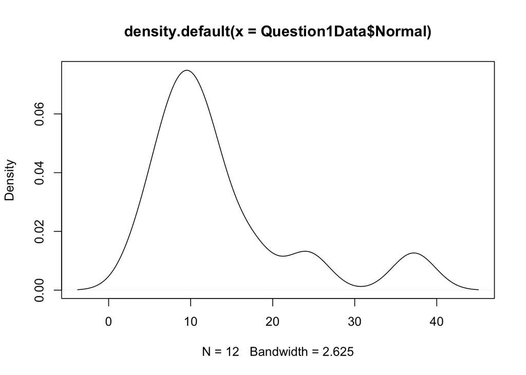

```r
#A ratio of 0.69 of IQR to Standard Deviation shows that the sample is not from a symmetric distribution.

#We can also see that from the plot
#Normal Plot
Normal_plot <- plot(density(Question1Data$Normal))
```

```r
#Plot shows right skewed data

#Checking for Diabetic Sample
IQR(Question1Data$Diabetic)/sd(Question1Data$Diabetic)
```

```
## [1] 1.73409
```

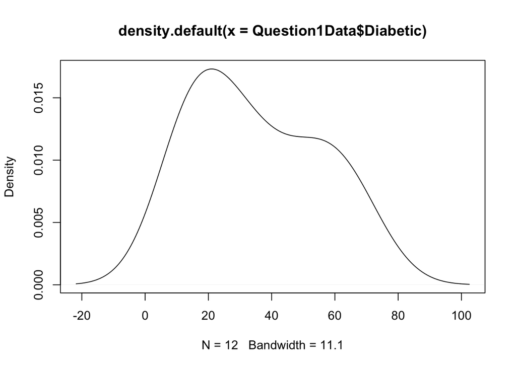

```r
#Here the ratio is close to 1.35 but still not close enough to assume that the sample comes from a normal distribution.

#We can also see that from the plot
Diabetic_plot <- plot(density(Question1Data$Diabetic))
```

```r
#Plot shows right skewed data.
```

**The Plot and the IQR to Standard Deviation ratio clearly show that the sample is not from a symmetric distribution.**

**2) Log and Square root Transformations**

```r
Normal_Transformed_log <- log(Question1Data$Normal)
Normal_Transformed_square_root <- sqrt(Question1Data$Normal)

IQR(Normal_Transformed_log)/sd(Normal_Transformed_log)
```

```
## [1] 0.9524558
```

```r
IQR(Normal_Transformed_square_root)/sd(Normal_Transformed_square_root)
```

```
## [1] 0.8520602
```

```r
#The ratio is better for the Log Transformation for the Normal Sample.

Diabetic_Transformed_log <- log(Question1Data$Diabetic)
Diabetic_Transformed_square_root <- sqrt(Question1Data$Diabetic)

IQR(Diabetic_Transformed_log)/sd(Diabetic_Transformed_log)
```

```
## [1] 1.737132
```

```r
IQR(Diabetic_Transformed_square_root)/sd(Diabetic_Transformed_square_root)
```

```
## [1] 1.766639
```

```r
#Here the ratio is almost comparable so we check the descriptive statistics of these 2 variables.
library(psych)
describe(Diabetic_Transformed_log)
```

```
##    vars  n mean   sd median trimmed  mad  min  max range  skew kurtosis
## X1    1 12 3.39 0.64   3.44     3.4 0.85 2.44 4.24  1.79 -0.16    -1.62
##      se
## X1 0.18
```

```r
describe(Diabetic_Transformed_square_root)
```

```
##    vars  n mean   sd median trimmed  mad  min  max range skew kurtosis  se
## X1    1 12  5.7 1.74   5.59    5.67 2.34 3.39 8.32  4.93 0.08    -1.65 0.5
```

```r
#We can see that the skewness is less for the square root transformation of the diabetic variable
```

**So, we see that the log transformation works better for Normal patients sample and square root transformation works better for Diabetic patients sample.**

**3.**

```r
summary(Normal_Transformed_log)
```

```
##    Min. 1st Qu.  Median    Mean 3rd Qu.    Max.
##   1.411   2.119   2.392   2.433   2.685   3.616
```

```r
IQR(Normal_Transformed_log)/sd(Normal_Transformed_log)
```

```
## [1] 0.9524558
```

```r
summary(Diabetic_Transformed_square_root)
```

```
##    Min. 1st Qu.  Median    Mean 3rd Qu.    Max.
##   3.391   4.167   5.594   5.700   7.246   8.319
```

```r
IQR(Diabetic_Transformed_square_root)/sd(Diabetic_Transformed_square_root)
```

```
## [1] 1.766639
```

**The variables transformed with chosen transformations look to be coming from approximate normal distribution as the mean median are very close to each other for the transformations but the IQR to SD ratio is a bit off from 1.35**

**4.** Let Delta be the difference between Diabetic Patients level and Normal Patients level

$H_0 : \Delta \le 0$

```r
t.test(log(Question1Data$Diabetic), log(Question1Data$Normal), alt = "greater")
```

```
##
##  Welch Two Sample t-test
##
## data:  log(Question1Data$Diabetic) and log(Question1Data$Normal)
## t = 3.8041, df = 21.9, p-value = 0.0004888
## alternative hypothesis: true difference in means is greater than 0
## 95 percent confidence interval:
##  0.5250797       Inf
## sample estimates:
## mean of x mean of y
##  3.390628  2.433349
```

```r
t.test(sqrt(Question1Data$Diabetic), sqrt(Question1Data$Normal), alt = "greater")
```

```
##
##  Welch Two Sample t-test
##
## data:  sqrt(Question1Data$Diabetic) and sqrt(Question1Data$Normal)
## t = 3.6496, df = 18.715, p-value = 0.0008696
## alternative hypothesis: true difference in means is greater than 0
## 95 percent confidence interval:
##  1.146177      Inf
## sample estimates:
## mean of x mean of y
##  5.700115  3.520447
```

**Ans 2** **a)** Since this is a larger sample than 30, we can use Welch test as Welch test is a robust test for large samples.

**b)**

```r
Money_mean<-16.8
NoMoney_mean<-24.3
Delta_hat<- NoMoney_mean - Money_mean

#We Do a Welch test for Delta where Delta is the difference in mean number of hours worked between No Money prisoners mean minus the Money prisoners mean
#Here Null Hypothis is Delta =0. So we will do a two-tailed test.

#Creating a function for Welch Test which calculates p value and confidence intervals
WelchTest<-function(Delta.hat,s1,s2,n1,n2,conf_int){
var1<- s1^2
var2<- s2^2
std.error <- sqrt(var1/n1 + var2/n2)
t.welch <- (Delta.hat - 0) / std.error
t.welch
#We find the degress of freedom now
DF <- (var1/n1 + var2/n2)^2 /
  ((var1/n1)^2/(n1-1) + (var2/n2)^2/(n2-1))
DF
#Finding p value for this Welch test
p_value<-1 - pt(t.welch, df = DF)
conf.int<-(1-(1 - conf_int )/2)
ci_lower<- Delta.hat - qt(conf.int, DF) * sqrt(var1) / sqrt(n1)
ci_higher<- Delta.hat + qt(conf.int, df = DF) * sqrt(var2) / sqrt(n2)
return(list(p_value,ci_lower,ci_higher))
}
#Calculating p-value for Alternative Hypothesis Less than Null
WelchTest(-Delta_hat,15.9,17.3,592,154,0.95)[[1]]
```

```
## [1] 0.999999
```

```r
#Calculating p-value for Alternative Hypothesis Greater than Null
WelchTest(Delta_hat,15.9,17.3,592,154,0.95)[[1]]
```

```
## [1] 1.045809e-06
```

**We get a very small p-value for this Welch test for Delta>0 and a very large value for Delta <0. So we can reject null hypothesis and say that Delta >0 or the prisoners who didn’t get any money OR the control group work more number of hours than the prisoners who got money upon release**

** c)**

```r
#Calculating Confidence interval lower bound
WelchTest(Delta_hat,15.9,17.3,592,154,0.95)[[2]]
```

```
## [1] 6.212259
```

```r
#Calculating Confidence interval upper bound
WelchTest(Delta_hat,15.9,17.3,592,154,0.95)[[3]]
```

```
## [1] 10.24712
```

**We can say with 95% confidence that the Control group work between 6.21 hrs to 10.24 hours more than the treatment group(Group that were given Money)**

**3 a)** We again have a large sample so we will use Welch Test for hypothesis testing. Here our null hypothesis is $H_0: Delta=0$ Where Delta is the difference in the means of the 2 groups. We will do two-tailed Welch test to check on either side of the null hypothesis

```r
n1<-100
n2<-100
mean_1<-61
mean_2<-59
sd1<-10
sd2<-13
Delta_Q3<-mean_1 - mean_2
#We do a two tailed Welch test
WelchTest(-Delta_Q3,10,13,100,100,0.95)[[1]]
```

```
## [1] 0.8878849
```

```r
WelchTest(Delta_Q3,10,13,100,100,0.95)[[1]]
```

```
## [1] 0.1121151
```

**We get a high p-value(0.89 and 0.11) on both sides of the null hypothesis at 95% confidence interval. So we fail to reject the null hypothesis and accept it. So there is no major difference between the 2 groups**

**b)**

```r
WelchTest(Delta_Q3,10,13,100,100,0.90)[[2]]
```

```
## [1] 0.3469029
```

```r
WelchTest(Delta_Q3,10,13,100,100,0.90)[[3]]
```

```
## [1] 4.149026
```

**So we can say with 90% confidence that the scores of group 1 are greater than group 2. The range is between 0.3469029 and 4.149026.**

**Ans: 4) a)** We can use one-tailed T-test. Here Delta is the difference in means between the aerobic levels of the treatment group and the control group. Null Hypothesis is: $H_0 = 0$ We can use t.test for calculating p-values as the sample size is less than 30.We can also use Welch test as the 2 vectors have unequal variances. For confidence interval we cannot get upper bound using t.test. So we will call our Welchtest function made above for calculating the confidence interval values.

**b)**

```r
treatment_group<-c(-2.3, -0.7, -0.2, 0.1, 0.5, 0.8, 0.9, 1.6, 2.0, 3.9, 4.5, 6.0)
control_group<-c(-2.9, -1.5, -0.9, -0.8, -0.7, -0.5, -0.2, 0.2, 0.6, 1.2, 1.9, 2.8)
var(treatment_group)
```

```
## [1] 5.562045
```

```r
var(control_group)
```

```
## [1] 2.375152
```

```r
m1_q4<-mean(treatment_group)
m2_q4<-mean(control_group)
Delta_Q4<- m1_q4 - m2_q4
sd1_q4<-sd(treatment_group)
sd2_q4<-sd(control_group)
n1_q4<-length(treatment_group)
n2_q4<-length(control_group)
t.test(treatment_group,control_group,alternative = "greater")
```

```
##
##  Welch Two Sample t-test
##
## data:  treatment_group and control_group
## t = 1.8341, df = 18.946, p-value = 0.0412
## alternative hypothesis: true difference in means is greater than 0
## 95 percent confidence interval:
##  0.08518192        Inf
## sample estimates:
##   mean of x   mean of y
##  1.42500000 -0.06666667
```

```r
WelchTest(Delta_Q4,sd1_q4,sd2_q4,n1_q4,n2_q4,0.95)[[2]]
```

```
## [1] 0.06643614
```

```r
WelchTest(Delta_Q4,sd1_q4,sd2_q4,n1_q4,n2_q4,0.95)[[3]]
```

```
## [1] 2.423018
```

**The p-value for this test is 0.04 which is enough to reject the null hypothesis and accept the alternative hypothesis that Delta >0 which means that average VO2 levels increased for the treatment group as compared to the control group**

**c)** **The confidence interval was calculated in the previous snippet of r code using Welch Test Function made above by me. We can be 95% sure that the confidence interval bounds between 0.066 to 2.423**

**d)** Our results conclude that average VO2 levels increased for the treatment group as compared to the control group by an average of 0.06 to 2.42

**Ans 5** **a)** The Patients are the Experiment unit over here. One measurement of glycemic index is performed on the experimental unit. This problem is with just one independent sample.

**b)** The Null hypothesis is that dates have the same effect on the glycemic index without the coffee. Alternate Hypothesis is that dates have different effect on the glycemic index with coffee. The t-statistic can be computed as follows:

```r
mean_difference <- 11.5
sd_test <- 21
n <- 10
t_stat <- mean_difference/(sd_test/sqrt(n))
t_stat
```

```
## [1] 1.731723
```

**c)** The given test was performed with only 10 samples. Even though the null hypothesis was accepted but we need to replicate this study with a larger sample size to conclude that on average, dates have the same glycemic index with or without co???ee

**Ans 6** **a)** **The Null hypothesis is that the students did better after listening to reggae music and their scores increased. The alternative hypothesis is that they did worse off OR their scores worsened.**

```r
mean_change_score <- 6.5
sd_score<- 12
n <- 61
t_statistic <- mean_change_score/(sd_score/sqrt(n))
t_statistic
```

```
## [1] 4.230552
```

```r
DF <- n-1
p_value <- pt(-t_statistic,DF)
p_value
```

```
## [1] 4.04772e-05
```